# Estimating Neighborhood Rents with Scraped Web Data

Chris Hess

June 2, 2018

Abstract

Online classified ads are a key source of information about local rental housing markets. This research asks what temporal and spatial dynamics explain neighborhood variations in one-bedroom rents in Seattle, WA, and contributes a novel approach to forecasting quarterly neighborhood rent levels using Bayesian models estimated with integrated nested Laplace approximations (INLA). All models were trained on data for 2017 Q2 through 2018 Q1, with forecasts for 2018 Q2 compared against the observed-to-date data for the current quarter (i.e. 2018 Q2). The top model assumes that spatial and temporal dynamics are separable, i.e. independent of each other, and non-interactive. This spatial random-effects model with AR(1) temporal structure achieves a mean absolute error (MAE) of about $90 for the training data and $145 for the test data.

Demand for rental housing units in Seattle, WA surged in the past decade, due to relative scarcity in available housing amidst a period of historic population growth. Growing shares of households are unable to buy a home short of “driving till they qualify”, and among households who rent a substantial share pay 30%, if not more of their incomes on their housing costs. The rising cost of housing therefore has a direct role in neighborhood processes of “demographic inversion” like urban gentrification and suburbanizing poverty. Census data (i.e. decennial and American Community Survey) have common currency among scholars and practitioners interested in metropolitan housing markets, but neverthless possess a substantial limitation for research in tight housing markets like Seattle—that is, at least two years elapse between data collection and publication, if not more. This publication schedules prohibit analyzing any market dynamics beyond long-term trends, particularly among smaller areas of aggregation like neighborhoods. While more up-to-date options for neighborhood rent data exist through privately-held companies, such data can be somewhat of a black box in their creation and may be biased towards the costs of corporate-held properties. This would-be problem for academic researchers creates an opportunity for applying web scraping methods to generate a novel data on housing availability and costs.

This study aims to demonstrate why scraped rental housing listings are a valuable source of data in subject areas such as housing studies and neighborhood demography through a set of descriptive analyses and models of quarterly rent levels among census tracts in Seattle, WA. Summaries of the Craigslist data show agreement with existing sources in their distribution but do suggest higher median levels for most neighborhoods, likely given the listings’ recent collection relative to other data. In a more general sense, the methods and frameworks used in this study also offer a template for efficiently collecting web data, conducting reproducible research, and publishing interactive results to GitHub. I start by briefly reviewing some background relevant to studying neighborhood rental housing. I then outline a process for automated web scraping of a rental listing source like Craigslist using a program called Helena, and compare aggregates from the collected rental listings with other data to assess rent agreement in measures. After describing the data and process, I present a set of models predicting neighborhood rent levels to understand different how different temporal and spatial structures fit the data. I conclude by discussing the promise of web data for subfields like housing studies and the value of R Markdown and GitHub for social science research.

## Background

Existing public data sources like the American Community Survey or decennial census theoretically have two sources of error relative to the ``true’‘median rent in a given overall market and to an even greater degree among neighborhood approximations like census tracts. Census sources of rental information cannot provide insight into any change in rental cost associated with newer developments becoming available (at least not until considerable time has already passed) given the temporal delay in data publication (i.e. ACS estimates are usually at least 2 years old, decennial many more). This feature of Census data is salient given newer housing units’ generally higher rents and greater-than-average vacancy, both factors which lead to underestimating the present levels of rents for available housing units when either the ACS or decennial census are used as a current indicator. For already-leased rental housing units that are sampled, the temporal lag generates measurement error such that data on a given building’s current asking rents may be underestimated relative to current tenants’ payment levels.

For-profit data sources play a role in filling the information gap about rental housing costs, though they tend to possess their own unique shortcomings. These data sources tend to rely on survey methodologies for data collection, and ask landlords in a given market to outline the average cost for units of a given bedroom size or other specification. In exchange for providing detailed information for their database, the rental data provider may give participating landlords and property management companies access to a slice of information generated via accumulated data. These data tend to be rather opaque in their collection methodologies, with larger or corporate-owner properties most likely to appear in these data relative to independently-owned (i.e. mom and pop) rental units.

## Data

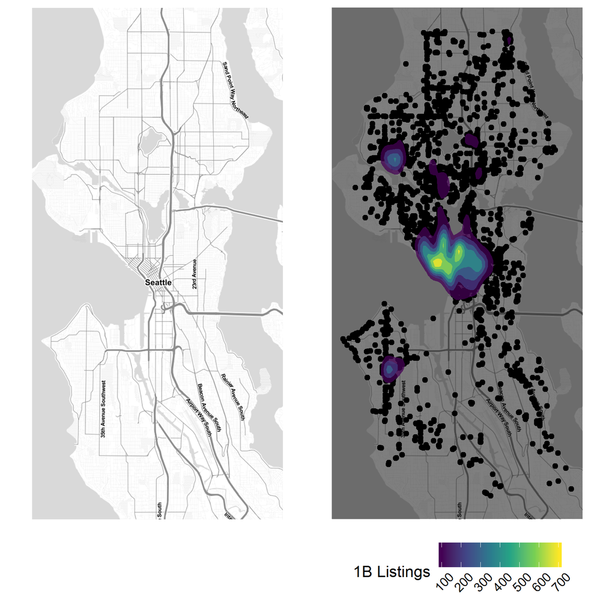

### Web scraping with Helena

### Data Processing

### Data Description

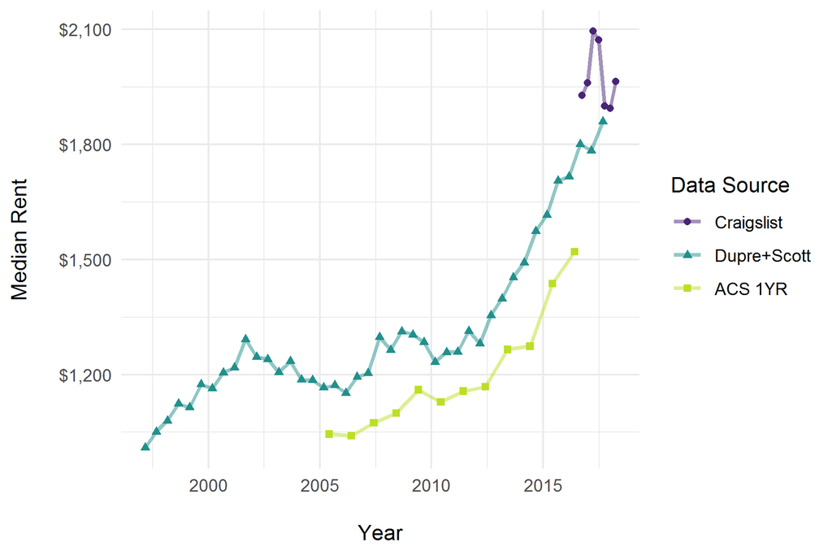

Figure 2. Time-series of median rent (all bedroom sizes) for Seattle, 1997-2018. Historical values adjusted with CPI; Craigslist estimates are quarterly, Dupre+Scott are semi-annual and ACS are annual (i.e. respective 1-Year Estimates for each year period).

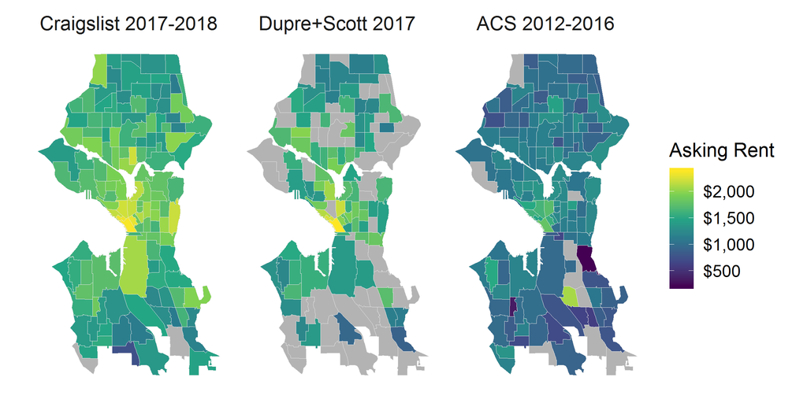

Figure 3. Chloropleth map of neighborhood 1-bedroom rents across Craigslist, Dupre+Scott and ACS 2012-2016 5-Year Estimates. Craigslist represents median asking rent among all one-bedroom listings, Dupre+Scott consists of median contract rents among one-bedroom units in 20+ unit properties, while ACS releases median gross (asking) rents for all one-bedroom renter-occupied housing units sampled.

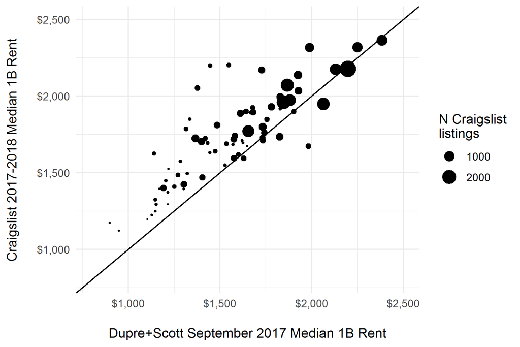

## Models

```
##
## Call:
## c("inla(formula = form.int, family = \"normal\", data = sea_df, control.compute = list(dic = TRUE, ",  "    waic = TRUE), control.predictor = list(compute = TRUE))" )
##
## Time used:
##  Pre-processing    Running inla Post-processing           Total
##          4.5332          2.6449          0.8006          7.9787
##
## Fixed effects:
##               mean     sd 0.025quant 0.5quant 0.975quant   mode kld
## (Intercept) 7.3676 0.0177     7.3329   7.3676     7.4023 7.3676   0
## QtrQ2       0.0676 0.0256     0.0174   0.0676     0.1178 0.0676   0
## QtrQ3       0.0755 0.0253     0.0258   0.0755     0.1251 0.0755   0
## QtrQ4       0.0214 0.0255    -0.0286   0.0214     0.0714 0.0214   0
##
## The model has no random effects
##
## Model hyperparameters:
##                                          mean    sd 0.025quant 0.5quant
## Precision for the Gaussian observations 25.36 1.615      22.29    25.32
##                                         0.975quant  mode
## Precision for the Gaussian observations      28.63 25.25
##
## Expected number of effective parameters(std dev): 4.074(0.0049)
## Number of equivalent replicates : 118.30
##
## Deviance Information Criterion (DIC) ...: -182.26
## Effective number of parameters .........: 5.115
##
## Watanabe-Akaike information criterion (WAIC) ...: -181.86
## Effective number of parameters .................: 5.445
##
## Marginal log-Likelihood:  62.19
## Posterior marginals for linear predictor and fitted values computed
```

```
##
## Call:
## c("inla(formula = form.ns, family = \"normal\", data = sea_df, control.compute = list(dic = TRUE, ",  "    waic = TRUE), control.predictor = list(compute = TRUE))" )
##
## Time used:
##  Pre-processing    Running inla Post-processing           Total
##          4.5362          2.6839          2.6879          9.9081
##
## Fixed effects:
##               mean     sd 0.025quant 0.5quant 0.975quant   mode kld
## (Intercept) 7.3626 0.0184     7.3264   7.3626     7.3987 7.3626   0
## QtrQ2       0.0533 0.0136     0.0266   0.0533     0.0801 0.0533   0
## QtrQ3       0.0654 0.0134     0.0390   0.0654     0.0917 0.0653   0
## QtrQ4       0.0035 0.0135    -0.0230   0.0035     0.0300 0.0035   0
##
## Random effects:
## Name   Model
##  idtract   IID model
##
## Model hyperparameters:
##                                          mean    sd 0.025quant 0.5quant
## Precision for the Gaussian observations 92.96 7.119      79.60    92.75
## Precision for idtract                   30.83 4.329      23.11    30.56
##                                         0.975quant  mode
## Precision for the Gaussian observations     107.62 92.39
## Precision for idtract                        40.13 30.06
##
## Expected number of effective parameters(std dev): 122.43(1.779)
## Number of equivalent replicates : 3.937
##
## Deviance Information Criterion (DIC) ...: -688.66
## Effective number of parameters .........: 124.14
##
## Watanabe-Akaike information criterion (WAIC) ...: -670.81
## Effective number of parameters .................: 116.64
##
## Marginal log-Likelihood:  205.29
## Posterior marginals for linear predictor and fitted values computed
```

```
##
## Call:
## c("inla(formula = form.nsar1, family = \"normal\", data = sea_df, ",  "    control.compute = list(dic = TRUE, waic = TRUE), control.predictor = list(compute = TRUE))" )
##
## Time used:
##  Pre-processing    Running inla Post-processing           Total
##          4.2811          6.0053          0.3223         10.6086
##
## Fixed effects:
##               mean     sd 0.025quant 0.5quant 0.975quant   mode kld
## (Intercept) 7.3926 0.0261     7.3402   7.3927     7.4445 7.3928   0
##
## Random effects:
## Name   Model
##  idtract   IID model
## idqtr   AR1 model
## idqtr1   IID model
##
## Model hyperparameters:
##                                              mean        sd 0.025quant
## Precision for the Gaussian observations 9.299e+01 7.120e+00    79.5460
## Precision for idtract                   3.079e+01 4.324e+00    23.0944
## Precision for idqtr                     3.040e+03 3.358e+03   391.0750
## Rho for idqtr                           2.993e-01 3.652e-01    -0.4779
## Precision for idqtr1                    1.717e+04 2.158e+04   458.7981
##                                          0.5quant 0.975quant     mode
## Precision for the Gaussian observations 9.281e+01  1.075e+02  92.5807
## Precision for idtract                   3.052e+01  4.009e+01  30.0053
## Precision for idqtr                     2.039e+03  1.180e+04 987.1305
## Rho for idqtr                           3.396e-01  8.684e-01   0.5134
## Precision for idqtr1                    1.003e+04  7.483e+04 826.6610
##
## Expected number of effective parameters(std dev): 121.95(1.823)
## Number of equivalent replicates : 3.952
##
## Deviance Information Criterion (DIC) ...: -688.53
## Effective number of parameters .........: 123.99
##
## Watanabe-Akaike information criterion (WAIC) ...: -670.52
## Effective number of parameters .................: 116.69
##
## Marginal log-Likelihood:  220.89
## Posterior marginals for linear predictor and fitted values computed
```

```
##
## Call:
## c("inla(formula = form.bym, family = \"normal\", data = sea_df, control.compute = list(dic = TRUE, ",  "    waic = TRUE), control.predictor = list(compute = TRUE))" )
##
## Time used:
##  Pre-processing    Running inla Post-processing           Total
##          4.2270          8.4660          0.3793         13.0723
##
## Fixed effects:
##               mean     sd 0.025quant 0.5quant 0.975quant   mode kld
## (Intercept) 7.3886 0.0222     7.3435   7.3887      7.433 7.3888   0
##
## Random effects:
## Name   Model
##  idtract   BYM model
## idqtr   AR1 model
## idqtr1   IID model
##
## Model hyperparameters:
##                                                mean        sd 0.025quant
## Precision for the Gaussian observations   9.217e+01 7.109e+00    78.8644
## Precision for idtract (iid component)     9.339e+01 2.442e+01    54.1697
## Precision for idtract (spatial component) 8.674e+01 2.837e+01    44.5633
## Precision for idqtr                       3.060e+03 3.251e+03   411.9009
## Rho for idqtr                             3.197e-01 3.596e-01    -0.4456
## Precision for idqtr1                      1.554e+04 1.940e+04   355.6382
##                                            0.5quant 0.975quant      mode
## Precision for the Gaussian observations     91.9438  1.068e+02   91.5473
## Precision for idtract (iid component)       90.4668  1.497e+02   84.9328
## Precision for idtract (spatial component)   82.2406  1.545e+02   74.0110
## Precision for idqtr                       2094.5879  1.152e+04 1041.1136
## Rho for idqtr                                0.3582  8.787e-01    0.5351
## Precision for idqtr1                      8986.4044  6.772e+04  560.6435
##
## Expected number of effective parameters(std dev): 114.26(2.959)
## Number of equivalent replicates : 4.218
##
## Deviance Information Criterion (DIC) ...: -691.64
## Effective number of parameters .........: 116.36
##
## Watanabe-Akaike information criterion (WAIC) ...: -673.25
## Effective number of parameters .................: 111.51
##
## Marginal log-Likelihood:  333.47
## Posterior marginals for linear predictor and fitted values computed
```

```
##
## Call:
## c("inla(formula = form.spt, family = \"normal\", data = sea_df, control.compute = list(dic = TRUE, ",  "    waic = TRUE), control.predictor = list(compute = TRUE), control.inla = list(correct = TRUE, ",  "    correct.factor = 10))")
##
## Time used:
##  Pre-processing    Running inla Post-processing           Total
##          4.0189         15.7312          0.4593         20.2094
##
## Fixed effects:
##               mean     sd 0.025quant 0.5quant 0.975quant   mode kld
## (Intercept) 7.3886 0.0221     7.3446   7.3886      7.432 7.3887   0
##
## Random effects:
## Name   Model
##  idtract   BYM model
## idqtr   AR1 model
## idqtr1   IID model
## idtractqtr   IID model
##
## Model hyperparameters:
##                                                mean        sd 0.025quant
## Precision for the Gaussian observations   1.505e+02 1.647e+01   108.7184
## Precision for idtract (iid component)     9.279e+01 2.417e+01    54.0859
## Precision for idtract (spatial component) 8.728e+01 2.848e+01    44.5746
## Precision for idqtr                       3.015e+03 3.502e+03   357.5617
## Rho for idqtr                             2.825e-01 3.794e-01    -0.5296
## Precision for idqtr1                      2.116e+04 2.648e+04   846.7641
## Precision for idtractqtr                  2.357e+02 3.988e+01   164.2896
##                                            0.5quant 0.975quant      mode
## Precision for the Gaussian observations   1.484e+02    200.868  150.8137
## Precision for idtract (iid component)     8.986e+01    148.570   84.3120
## Precision for idtract (spatial component) 8.293e+01    155.249   74.9124
## Precision for idqtr                       1.967e+03  12078.116  906.5765
## Rho for idqtr                             3.288e-01      0.865    0.5237
## Precision for idqtr1                      1.276e+04  90948.407 1963.4654
## Precision for idtractqtr                  2.268e+02    341.861  224.7025
##
## Expected number of effective parameters(std dev): 261.34(41.05)
## Number of equivalent replicates : 1.844
##
## Deviance Information Criterion (DIC) ...: -799.87
## Effective number of parameters .........: 259.46
##
## Watanabe-Akaike information criterion (WAIC) ...: -797.34
## Effective number of parameters .................: 200.03
##
## Marginal log-Likelihood:  331.47
## Posterior marginals for linear predictor and fitted values computed
```

| train_test | int_rmse | ns_rmse | nsar1_rmse | bym_rmse | spt_rmse | int_mae | ns_mae | nsar1_mae | bym_mae | spt_mae |
| --- | --- | --- | --- | --- | --- | --- | --- | --- | --- | --- |
| Test | 309.0099 | 214.7089 | 206.7180 | 199.1201 | 211.27234 | 254.0486 | 154.08055 | 147.61005 | 141.22125 | 151.73167 |
| Training | 325.0620 | 141.2202 | 141.6717 | 143.7027 | 87.15668 | 260.6634 | 93.81771 | 93.98435 | 96.53357 | 57.86032 |

## Results

## Discussion

## References